# Comparing wood density databases

Author

G. Bediaga

Published

January 8, 2026

# Introduction

This script will compare biomass estimations with different wood density databases. We will use Global Wood Database (Chave et al. 2009), from the package `BIOMASS` and the Brazilian Woods Database (https://lpf.florestal.gov.br/en-us/brazilian-woods).

# Setup

```r
library(here)
library(dplyr)
library(sf)
library(ggplot2)
library(ggrepel)
library(readr)
library(rnaturalearth)
library(rnaturalearthdata)
library(BIOMASS)
```

# Comparing different wood databases

```r
bwd <- read.csv(here("data/wood_density/tabela_densidade_coordenadas.csv"))

bwd_clean <- bwd %>%
  filter(!is.na(long), !is.na(lat))

pts_bwd <- st_as_sf(
  bwd_clean,
  coords = c("long", "lat"),
  crs = 4326   # WGS84 (graus decimais)
)

pts_bwd_count <- pts_bwd %>%
  st_coordinates() %>%
  as.data.frame() %>%
  group_by(X, Y) %>%
  summarise(n = n()) %>%
  ungroup() %>%
  st_as_sf(coords = c("X", "Y"), crs = st_crs(pts_bwd))
```

[output not shown]

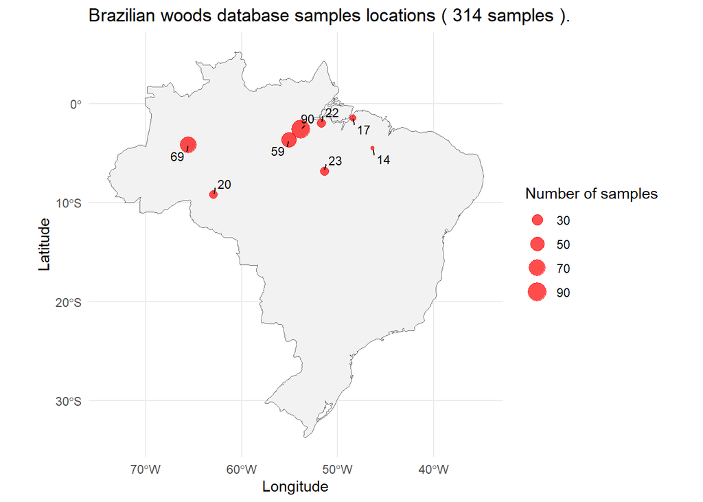

```r
brasil <- ne_countries(
  scale = "medium",
  country = "Brazil",
  returnclass = "sf"
)

# ggplot() +
#   geom_sf(data = brasil, fill = "gray95", color = "gray40") +
#   geom_sf(data = pts_bwd, color = "red", size = 2, alpha = 0.7) +
#   coord_sf() +
#   theme_minimal() +
#   labs(
#     title = "Brazilian woods database samples locations",
#     x = "Longitude",
#     y = "Latitude"
#   )

ggplot() +
  geom_sf(data = brasil,
          fill = "gray95",
          color = "gray40") +
  geom_sf(data = pts_bwd_count,
          aes(size = n),
          color = "red",
          alpha = 0.7) +
  geom_text_repel(
    data = pts_bwd_count,
    aes(label = n,
        geometry = geometry),
    stat = "sf_coordinates",
    size = 3,
    min.segment.length = 0
  ) +
  scale_size_continuous(name = "Number of samples") +
  coord_sf() +
  theme_minimal() +
  labs(
    title = paste("Brazilian woods database samples locations (",
                  nrow(pts_bwd),
                  "samples )."),
            x = "Longitude",
            y = "Latitude"
  )
```

# Estimating biomass with BWD

We will use permanent plots measurements from Jamari National Forest. The Wood density estimates presented here are only for species the species present in the permanent plots.

In BWD there are multiple samples for the same species. We calculated mean basic wood density for each species with multiple samples. Then we converted bwd table to `BIOMASS` wood density table format.

We retrieved wood density from Gobal Wood Database (Chave et al. 2009) using `BIOMASS`.

```r
pps <- read.csv(here("data/pp/tabelao_pps.csv"))

message("Permanent plots of APUs: \n",paste(unique(paste(pps$UMF,
                                                         pps$UPA)),
                                                         collapse = "\n"
                                                         ))
```

```
Permanent plots of APUs:
UMF_I UPA_1
UMF_I UPA_10
UMF_I UPA_13
UMF_I UPA_2
UMF_I UPA_3
UMF_I UPA_4
UMF_I UPA_5
UMF_I UPA_6
UMF_I UPA_7
UMF_I UPA_8
UMF_I UPA_9
UMF_IV UPA_15
```

```r
message("Years of measurement:\n",paste(unique(pps$p23_cdmedicao),
                                         collapse = "\n"))
```

```
Years of measurement:
2010
2013
2016
2018
2021
2015
2017
2023
2020
2022
2011
2012
2014
2019
```

```r
bwd <- bwd %>%
  group_by(nome_cientifico) %>%
  summarise(mean_wd = mean(densidade_basica),
            .groups = "drop")

bwd_biomass <- bwd %>%
  tidyr::separate("nome_cientifico",
                  c("genero","epiteto"),
                  " ")
names(bwd_biomass) <- c("genus","species","wd")

message("BWD has wood density of ",
        length(unique(bwd$nome_cientifico)),
        " species.")
```

```
BWD has wood density of 275 species.
```

```r
taxo <- correctTaxo(genus=pps$genero,
                    species=pps$epiteto,
                    useCache = T)
```

```
Cache updated
```

```
Source iplant_tnrs:41090
```

```
Corrections TaxaNotFound:10183, FALSE:21919, TRUE:1336, SpNotFound:7652
```

```r
w_density <- getWoodDensity(genus = taxo$genusCorrected,
                            species = taxo$speciesCorrected)
```

```
The reference dataset contains 16467 wood density values
```

```
Your taxonomic table contains 106 taxa
```

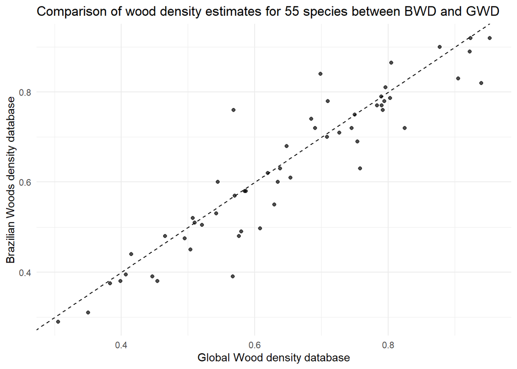

```r
densidades <- bwd_biomass %>%
                  inner_join(w_density,
                  by = c("genus",
                         "species")) %>%
                  select(genus,
                         species,
                         WD_global = meanWD,
                         WD_brazil = wd)

densidades <- unique(densidades)

ggplot(densidades, aes(x = WD_global,
                       y = WD_brazil)) +
  geom_point(alpha = 0.7) +
  geom_abline(slope = 1,
              intercept = 0,
              linetype = "dashed") +
  labs(
    x = "Global Wood density database",
    y = "Brazilian Woods density database",
    title = paste("Comparison of wood density estimates for",
                  nrow(densidades),
                  "species between BWD and GWD")
  ) +
  theme_minimal()
```

We can use Bland-Altman graphic to see differences between wood density databases. I will highlight species that are out of limits of agreement.

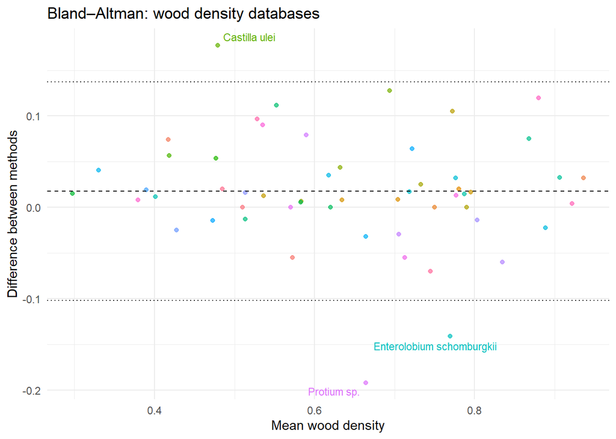

```r
densidades$mean_density <- (densidades$WD_global + densidades$WD_brazil) / 2
densidades$diff_density <- densidades$WD_global - densidades$WD_brazil

bias <- mean(densidades$diff_density,
             na.rm = TRUE)
sd_diff <- sd(densidades$diff_density,
              na.rm = TRUE)

loa_inf <- bias - 1.96 * sd_diff
loa_sup <- bias + 1.96 * sd_diff

densidades <- densidades %>%
                 mutate(fora_loa = diff_density < loa_inf | diff_density > loa_sup)

densidades$especie <- paste(densidades$genus,
                            densidades$species,
                            sep = " ")

ggplot(densidades, aes(x = mean_density,
                       y = diff_density,
                       color = especie)) +
  geom_point(alpha = 0.7) +
  geom_hline(yintercept = mean(densidades$diff_density,
                               na.rm = TRUE),
             linetype = "dashed") +
  geom_hline(yintercept = mean(densidades$diff_density,
                               na.rm = TRUE) +
                           1.96 * sd(densidades$diff_density,
                                     na.rm = TRUE),
             linetype = "dotted") +
  geom_hline(yintercept = mean(densidades$diff_density,
                               na.rm = TRUE) -
                           1.96 * sd(densidades$diff_density,
                                     na.rm = TRUE),
             linetype = "dotted") +
    geom_text_repel(
    data = subset(densidades, fora_loa),
    aes(label = especie),
    size = 3,
    show.legend = FALSE
  ) +
  labs(
    x = "Mean wood density",
    y = "Difference between methods",
    title = "Bland–Altman: wood density databases"
  ) +
  theme_minimal() +
  theme(legend.position = "none")
```

Let’s see the difference in biomass estimation.

Total tree height was obtained using the `retrieveH` function from the `BIOMASS` package, based on the central coordinates of the Jamari National Forest (Flona de Jamari). Biomass was estimated using the `computeAGB` function from the `BIOMASS` package, using the total height derived from `retrieveH` and the two wood density databases (the Global Wood Density Database and the Brazilian Wood Density Database). The BWD does not provide estimates of basic wood density for all species. When species-level values are unavailable, estimates from Global Wood Database will be used.

Each point represents one year of measurement for a plot. I will highlight plots with biomass estimation out of limits of agreement.

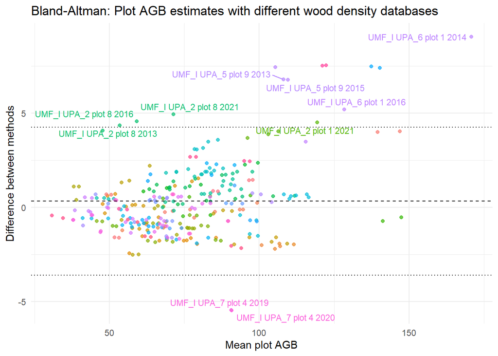

```r
w_density_BR <- left_join(w_density,
                          bwd_biomass,
                          by = c("species",
                                 "genus"),
                          multiple = "any") %>%

                mutate(wd = ifelse(!is.na(wd),
                                   wd,
                                   meanWD)) %>%
                select(family,
                       genus,
                       species,
                       wd)


altura <- retrieveH(D = pps$diametrocm,
                    coord = c(-62.99,
                                   -9.11
                                   ))


pps$altura <- altura$H

pps$AGB_Global <- computeAGB(D = pps$diametrocm,
                             WD = w_density$meanWD,
                             H = pps$altura)

pps$AGB_Brazilian <- computeAGB(D = pps$diametrocm,
                                WD = w_density_BR$wd,
                                H = pps$altura)

pps$plot <- paste(pps$UMF,pps$UPA,
                  "plot",
                  pps$p23_cdparcela,
                  pps$p23_cdmedicao)


pps_plots <- pps %>%
              group_by(plot,
                       p23_cdmedicao) %>%
              summarise("AGB_Global" = sum(AGB_Global),
                        "AGB_Brazilian" = sum(AGB_Brazilian))

pps_plots$mean_density <- (pps_plots$AGB_Global + pps_plots$AGB_Brazilian) / 2
pps_plots$diff_density <- pps_plots$AGB_Global - pps_plots$AGB_Brazilian

bias <- mean(pps_plots$diff_density,
             na.rm = TRUE)
sd_diff <- sd(pps_plots$diff_density,
              na.rm = TRUE)

loa_inf <- bias - 1.96 * sd_diff
loa_sup <- bias + 1.96 * sd_diff

pps_plots <- pps_plots %>%
            mutate(fora_loa = diff_density < loa_inf | diff_density > loa_sup)


ggplot(pps_plots, aes(x = mean_density,
                      y = diff_density,
                      color = plot)) +
  geom_point(alpha = 0.7) +
  geom_hline(yintercept = mean(pps_plots$diff_density,
                               na.rm = TRUE),
             linetype = "dashed") +
  geom_hline(yintercept = mean(pps_plots$diff_density,
                               na.rm = TRUE) +
                           1.96 * sd(pps_plots$diff_density,
                                     na.rm = TRUE),
             linetype = "dotted") +
  geom_hline(yintercept = mean(pps_plots$diff_density,
                               na.rm = TRUE) -
                           1.96 * sd(pps_plots$diff_density,
                                     na.rm = TRUE),
             linetype = "dotted") +
    geom_text_repel(
    data = subset(pps_plots,
                  fora_loa),
    aes(label = plot),
    size = 3,
    show.legend = FALSE
  ) +
  labs(
    x = "Mean plot AGB",
    y = "Difference between methods",
    title = "Bland-Altman: Plot AGB estimates with different wood density databases"
  ) +
  theme_minimal() +
  theme(legend.position = "none")
```

## References

Chave, Jerome, David Coomes, Steven Jansen, Simon L. Lewis, Nathan G. Swenson, and Amy E. Zanne. 2009. “Towards a Worldwide Wood Economics Spectrum.” *Ecology Letters* 12: 351–66. https://doi.org/10.1111/j.1461-0248.2009.01285.x.